# 131 years of American baby names, in plain SQL

**1.69 million name-and-sex rows and 322 million births, 1880 to 2010**, from the US Social Security Administration. Names are a good playground for window functions because every question is about **change over time inside a group**: a name's rank within its year, a name against itself a year earlier, a streak of consecutive years. The toolbox: `RANK()` and a windowed `SUM()` for shares, a running total to count how many names it takes to cover half the children, **gaps and islands** for streaks at number one, `LAG()` for one-year jumps, conditional aggregation for pivots, and a **recursive CTE** that builds a calendar so that a name's missing years count as zeros.

The data lists every name given to at least five babies of one sex in a year, so rare names are missing and yearly totals are a little lower than real births. Python only runs the queries and draws the charts.

```python
import os
import sqlite3
from pathlib import Path

import matplotlib.pyplot as plt
import numpy as np
import pandas as pd

DB_PATH = Path(os.environ.get("BABY_NAMES_DB", "baby_names.db"))
PINK, BLUE, GREY, AMBER = "#d6678f", "#2b6cb0", "#a0aec0", "#e8a33d"
plt.rcParams.update({"axes.spines.top": False, "axes.spines.right": False, "axes.grid": True,
                     "grid.alpha": 0.25, "figure.dpi": 110})
pd.set_option("display.width", 120)
pd.set_option("display.max_columns", 20)

con = sqlite3.connect(DB_PATH)


def q(sql):
    """Run a query and return the result as a DataFrame."""
    return pd.read_sql_query(sql, con)
```

## 0. What is in the database?

```python
tables = q("SELECT name FROM sqlite_master WHERE type = 'table' ORDER BY name").name
pd.DataFrame({"table": tables,
              "rows": [con.execute(f'SELECT COUNT(*) FROM "{t}"').fetchone()[0] for t in tables]})
```

|  | table | rows |
| --- | --- | --- |
| 0 | names | 1690784 |

## 1. Do parents still pick from the same few names?

`RANK()` orders the names inside each year and sex, and a windowed `SUM()` gives the year's total, so the births of the ten most popular names become a share. The number of distinct names per thousand births measures the opposite: variety.

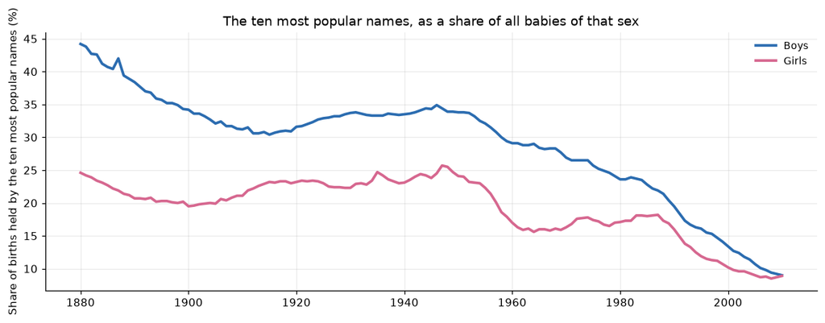

|  | year | sex | distinct_names | top10_pct | names_per_1000_births |
| --- | --- | --- | --- | --- | --- |
| 0 | 1880 | F | 942 | 24.6 | 10.4 |
| 1 | 1880 | M | 1058 | 44.2 | 9.6 |
| 90 | 1925 | F | 5774 | 23.0 | 4.7 |
| 91 | 1925 | M | 4869 | 32.9 | 4.4 |
| 140 | 1950 | F | 6105 | 24.1 | 3.6 |
| 141 | 1950 | M | 4195 | 33.8 | 2.3 |
| 190 | 1975 | F | 10598 | 17.4 | 7.3 |
| 191 | 1975 | M | 6324 | 25.7 | 4.1 |
| 240 | 2000 | F | 17649 | 10.2 | 9.7 |
| 241 | 2000 | M | 12109 | 13.4 | 6.2 |
| 260 | 2010 | F | 19698 | 8.9 | 11.2 |
| 261 | 2010 | M | 14140 | 9.0 | 7.4 |

```python
concentration = q("""
WITH ranked AS (
    SELECT year, sex, births,
           RANK() OVER (PARTITION BY year, sex ORDER BY births DESC) AS rnk,
           SUM(births) OVER (PARTITION BY year, sex)                 AS total_births
    FROM names
)
SELECT year, sex,
       COUNT(*)                                                                         AS distinct_names,
       ROUND(100.0 * SUM(CASE WHEN rnk <= 10 THEN births END) / MAX(total_births), 1)   AS top10_pct,
       ROUND(1000.0 * COUNT(*) / MAX(total_births), 1)                                  AS names_per_1000_births
FROM ranked
GROUP BY year, sex
ORDER BY year, sex
""")

fig, ax = plt.subplots(figsize=(10.5, 4))
for sex, color, label in (("M", BLUE, "Boys"), ("F", PINK, "Girls")):
    d = concentration[concentration.sex == sex]
    ax.plot(d.year, d.top10_pct, color=color, lw=2.4, label=label)
ax.set_ylabel("Share of births held by the ten most popular names (%)")
ax.legend(frameon=False, fontsize=9)
ax.set_title("The ten most popular names, as a share of all babies of that sex")
fig.tight_layout()
plt.show()  # use plt.savefig(...) to save instead

concentration[concentration.year.isin([1880, 1925, 1950, 1975, 2000, 2010])]
```

## 2. How many names does it take to name half of all children?

A running total over the names ordered from most to least popular (`SUM() OVER (... ROWS UNBOUNDED PRECEDING)`) divided by the year's total gives the cumulative share. The first name at which it reaches 50% is the answer.

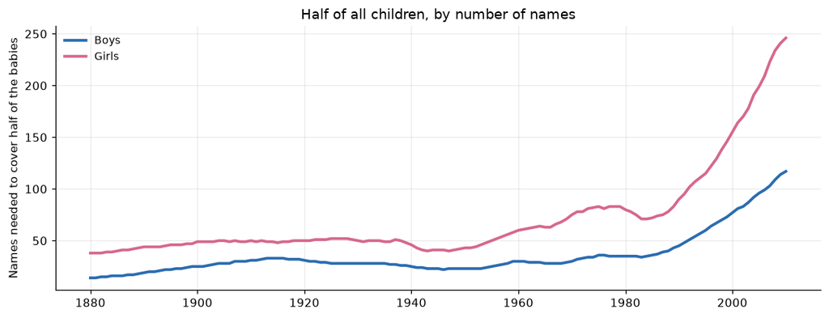

| sex year | F | M |
| --- | --- | --- |
| 1880 | 38 | 14 |
| 1925 | 52 | 28 |
| 1950 | 43 | 23 |
| 1975 | 83 | 36 |
| 2000 | 155 | 77 |
| 2010 | 246 | 117 |

```python
half = q("""
WITH r AS (
    SELECT year, sex,
           ROW_NUMBER() OVER (PARTITION BY year, sex ORDER BY births DESC, name) AS n,
           1.0 * SUM(births) OVER (PARTITION BY year, sex ORDER BY births DESC, name ROWS UNBOUNDED PRECEDING)
               / SUM(births) OVER (PARTITION BY year, sex)                       AS cum_share
    FROM names
)
SELECT year, sex, MIN(n) AS names_for_half
FROM r
WHERE cum_share >= 0.5
GROUP BY year, sex
ORDER BY year, sex
""")

fig, ax = plt.subplots(figsize=(10, 3.9))
for sex, color, label in (("M", BLUE, "Boys"), ("F", PINK, "Girls")):
    d = half[half.sex == sex]
    ax.plot(d.year, d.names_for_half, color=color, lw=2.4, label=label)
ax.set_ylabel("Names needed to cover half of the babies")
ax.legend(frameon=False, fontsize=9)
ax.set_title("Half of all children, by number of names")
fig.tight_layout()
plt.show()  # use plt.savefig(...) to save instead

half[half.year.isin([1880, 1925, 1950, 1975, 2000, 2010])].pivot(index="year", columns="sex", values="names_for_half")
```

## 3. The most common names ever given

Total births by name and sex over the whole period, with `RANK()` and the share of all babies of that sex (a windowed `SUM(SUM(...))`, an aggregate inside a window).

```python
alltime = q("""
SELECT RANK() OVER (ORDER BY SUM(births) DESC)                                        AS rank,
       name, sex,
       SUM(births)                                                                    AS births,
       ROUND(100.0 * SUM(births) / SUM(SUM(births)) OVER (PARTITION BY sex), 2)       AS pct_of_sex,
       COUNT(*)                                                                       AS years_listed
FROM names
GROUP BY name, sex
ORDER BY rank
LIMIT 10
""")

alltime
```

|  | rank | name | sex | births | pct_of_sex | years_listed |
| --- | --- | --- | --- | --- | --- | --- |
| 0 | 1 | James | M | 5049727 | 3.11 | 131 |
| 1 | 2 | John | M | 5040319 | 3.10 | 131 |
| 2 | 3 | Robert | M | 4767995 | 2.94 | 131 |
| 3 | 4 | Michael | M | 4243903 | 2.61 | 131 |
| 4 | 5 | Mary | F | 4103935 | 2.57 | 131 |
| 5 | 6 | William | M | 3986586 | 2.45 | 131 |
| 6 | 7 | David | M | 3525961 | 2.17 | 131 |
| 7 | 8 | Richard | M | 2542735 | 1.57 | 131 |
| 8 | 9 | Joseph | M | 2519280 | 1.55 | 131 |
| 9 | 10 | Charles | M | 2335387 | 1.44 | 131 |

## 4. Who held number one, and for how long?

The name at rank 1 in each year and sex, then the **gaps-and-islands** trick: the year minus a row number is constant inside an unbroken run, so grouping by it gives each streak.

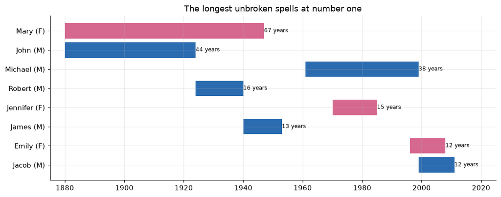

|  | sex | name | from_year | to_year | years_at_no1 |
| --- | --- | --- | --- | --- | --- |
| 0 | F | Mary | 1880 | 1946 | 67 |
| 1 | M | John | 1880 | 1923 | 44 |
| 2 | M | Michael | 1961 | 1998 | 38 |
| 3 | M | Robert | 1924 | 1939 | 16 |
| 4 | F | Jennifer | 1970 | 1984 | 15 |
| 5 | M | James | 1940 | 1952 | 13 |
| 6 | F | Emily | 1996 | 2007 | 12 |
| 7 | M | Jacob | 1999 | 2010 | 12 |
| 8 | F | Mary | 1953 | 1961 | 9 |
| 9 | F | Lisa | 1962 | 1969 | 8 |
| 10 | F | Jessica | 1985 | 1990 | 6 |
| 11 | F | Linda | 1947 | 1952 | 6 |

```python
streaks = q("""
WITH top AS (
    SELECT year, sex, name
    FROM (SELECT year, sex, name, RANK() OVER (PARTITION BY year, sex ORDER BY births DESC) AS rnk FROM names)
    WHERE rnk = 1
),
n AS (
    SELECT sex, name, year, year - ROW_NUMBER() OVER (PARTITION BY sex, name ORDER BY year) AS grp
    FROM top
)
SELECT sex, name, MIN(year) AS from_year, MAX(year) AS to_year, COUNT(*) AS years_at_no1
FROM n
GROUP BY sex, name, grp
ORDER BY years_at_no1 DESC
LIMIT 12
""")

top = streaks.head(8).iloc[::-1]
fig, ax = plt.subplots(figsize=(10, 4))
ax.barh([f"{n} ({s})" for n, s in zip(top.name, top.sex)], top.years_at_no1, left=top.from_year,
        color=[PINK if s == "F" else BLUE for s in top.sex])
for i, (to, yrs) in enumerate(zip(top.to_year, top.years_at_no1)):
    ax.text(to + 1, i, f"{yrs} years", va="center", fontsize=8)
ax.set_xlim(1875, 2025)
ax.set_title("The longest unbroken spells at number one")
fig.tight_layout()
plt.show()  # use plt.savefig(...) to save instead

streaks
```

## 5. Which names jumped overnight?

`LAG()` brings the previous year's births onto the same row, so the one-year growth ratio is a column. The filter keeps real spikes: at least 200 births the year before and at least 1,500 extra births.

```python
jumps = q("""
WITH s AS (
    SELECT name, sex, year, births,
           LAG(births) OVER (PARTITION BY name, sex ORDER BY year) AS prev,
           LAG(year)   OVER (PARTITION BY name, sex ORDER BY year) AS prev_year
    FROM names
)
SELECT name, sex, year, prev AS births_year_before, births, ROUND(1.0 * births / prev, 1) AS times_more, births - prev AS extra_births
FROM s
WHERE prev_year = year - 1 AND prev >= 200 AND births - prev >= 1500
ORDER BY times_more DESC
LIMIT 12
""")

jumps
```

|  | name | sex | year | births_year_before | births | times_more | extra_births |
| --- | --- | --- | --- | --- | --- | --- | --- |
| 0 | Tammy | F | 1957 | 261 | 4361 | 16.7 | 4100 |
| 1 | Kiara | F | 1989 | 222 | 2624 | 11.8 | 2402 |
| 2 | Ashanti | F | 2002 | 281 | 2944 | 10.5 | 2663 |
| 3 | Dawson | M | 1998 | 209 | 1895 | 9.1 | 1686 |
| 4 | Jaime | F | 1976 | 914 | 7838 | 8.6 | 6924 |
| 5 | Marlene | F | 1931 | 307 | 2583 | 8.4 | 2276 |
| 6 | Bentley | M | 2010 | 521 | 3742 | 7.2 | 3221 |
| 7 | Kayla | F | 1982 | 318 | 2275 | 7.2 | 1957 |
| 8 | Iesha | F | 1991 | 285 | 1897 | 6.7 | 1612 |
| 9 | Tristan | M | 1995 | 492 | 3088 | 6.3 | 2596 |
| 10 | Mandy | F | 1975 | 444 | 2709 | 6.1 | 2265 |
| 11 | Shanice | F | 1992 | 304 | 1857 | 6.1 | 1553 |

## 6. What does a spike look like?

Four of the names from the table above, followed over the years around their jump.

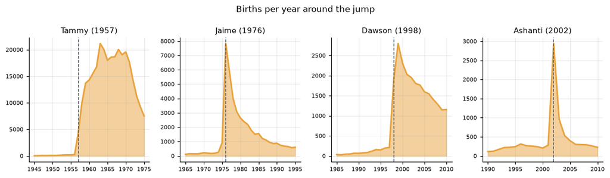

| name | min | max |
| --- | --- | --- |
| Ashanti | 113 | 2944 |
| Dawson | 28 | 2801 |
| Jaime | 111 | 7838 |
| Tammy | 45 | 21185 |

```python
spikes = q("""
SELECT name, year, births
FROM names
WHERE (name = 'Tammy' AND sex = 'F' AND year BETWEEN 1945 AND 1975)
   OR (name = 'Jaime' AND sex = 'F' AND year BETWEEN 1965 AND 1995)
   OR (name = 'Dawson' AND sex = 'M' AND year BETWEEN 1985 AND 2010)
   OR (name = 'Ashanti' AND sex = 'F' AND year BETWEEN 1990 AND 2010)
ORDER BY name, year
""")

fig, axes = plt.subplots(1, 4, figsize=(11, 3.2))
for ax, (name, jump) in zip(axes, (("Tammy", 1957), ("Jaime", 1976), ("Dawson", 1998), ("Ashanti", 2002))):
    d = spikes[spikes.name == name]
    ax.fill_between(d.year, d.births, color=AMBER, alpha=0.5)
    ax.plot(d.year, d.births, color=AMBER, lw=2)
    ax.axvline(jump, color="#4a5568", ls="--", lw=1)
    ax.set_title(f"{name} ({jump})", fontsize=10)
    ax.tick_params(labelsize=7)
fig.suptitle("Births per year around the jump", fontsize=11)
fig.tight_layout()
plt.show()  # use plt.savefig(...) to save instead

spikes.groupby('name').births.agg(['min', 'max'])
```

## 7. Which names changed sex?

Conditional aggregation pivots each name into the share of girls by decade; a window `MIN` and `MAX` per name keep the names that were almost entirely male in some decade and almost entirely female in another (at least 50,000 births in total, 500 per decade).

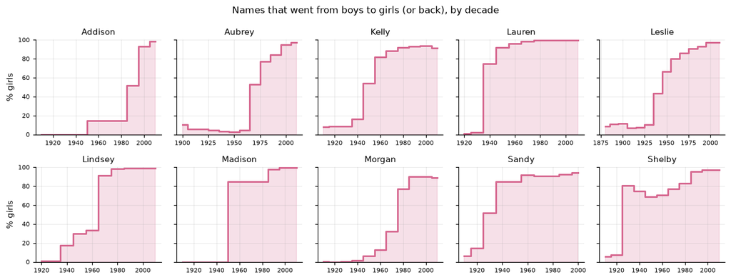

| decade name | 1880 | 1890 | 1900 | 1910 | 1920 | 1930 | 1940 | 1950 | 1960 | 1970 | 1980 | 1990 | 2000 | 2010 |
| --- | --- | --- | --- | --- | --- | --- | --- | --- | --- | --- | --- | --- | --- | --- |
| Addison | NaN | NaN | NaN | 0.0 | 0.0 | NaN | NaN | NaN | NaN | NaN | 14.4 | 51.6 | 93.1 | 98.2 |
| Aubrey | NaN | NaN | 10.5 | 5.4 | 5.8 | 4.4 | 3.2 | 2.7 | 4.8 | 52.7 | 77.3 | 84.5 | 95.1 | 97.4 |
| Kelly | NaN | NaN | NaN | 7.8 | 8.5 | 8.9 | 16.4 | 54.0 | 82.1 | 88.5 | 91.8 | 93.1 | 93.4 | 91.3 |
| Lauren | NaN | NaN | NaN | NaN | 0.9 | 2.3 | 74.8 | 92.2 | 96.2 | 98.3 | 99.4 | 99.7 | 99.7 | 99.8 |
| Leslie | 8.9 | 11.1 | 11.3 | 6.9 | 7.6 | 10.6 | 43.4 | 66.8 | 79.9 | 86.2 | 90.9 | 93.2 | 97.0 | 97.1 |
| Lindsey | NaN | NaN | NaN | NaN | 0.8 | 1.2 | 17.6 | 30.0 | 33.3 | 91.6 | 98.5 | 99.1 | 99.2 | 99.0 |
| Madison | NaN | NaN | NaN | 0.0 | 0.0 | NaN | NaN | NaN | NaN | NaN | 85.0 | 97.7 | 99.5 | 99.7 |
| Morgan | NaN | NaN | NaN | 0.4 | 0.0 | 0.4 | 1.7 | 6.3 | 12.8 | 32.1 | 77.1 | 90.0 | 90.0 | 89.1 |
| Sandy | NaN | NaN | NaN | 6.1 | 14.6 | 51.8 | 85.1 | 84.9 | 92.0 | 90.7 | 90.8 | 92.6 | 94.3 | NaN |
| Shelby | NaN | NaN | NaN | 5.5 | 7.2 | 80.5 | 74.9 | 69.0 | 70.4 | 77.4 | 83.0 | 95.7 | 97.4 | 97.4 |

```python
flips = q("""
WITH big AS (
    SELECT name FROM names GROUP BY name HAVING SUM(births) >= 50000
),
d AS (
    SELECT name, (year / 10) * 10 AS decade,
           SUM(CASE WHEN sex = 'F' THEN births ELSE 0 END) AS girls,
           SUM(births)                                      AS births
    FROM names
    WHERE name IN (SELECT name FROM big)
    GROUP BY name, decade
    HAVING SUM(births) >= 500
),
s AS (
    SELECT name, decade, births, ROUND(100.0 * girls / births, 1) AS girls_pct,
           MIN(100.0 * girls / births) OVER (PARTITION BY name) AS lowest,
           MAX(100.0 * girls / births) OVER (PARTITION BY name) AS highest
    FROM d
)
SELECT name, decade, births, girls_pct
FROM s
WHERE lowest < 10 AND highest > 90
ORDER BY name, decade
""")

names = flips.name.unique()
fig, axes = plt.subplots(2, 5, figsize=(12, 4.6), sharey=True)
for ax, name in zip(axes.ravel(), names):
    d = flips[flips.name == name]
    ax.step(d.decade, d.girls_pct, where="mid", color=PINK, lw=2)
    ax.fill_between(d.decade, d.girls_pct, step="mid", color=PINK, alpha=0.2)
    ax.set_title(name, fontsize=10)
    ax.set_ylim(0, 100)
    ax.tick_params(labelsize=7)
for ax in axes.ravel()[len(names):]:
    ax.axis("off")
axes[0, 0].set_ylabel("% girls")
axes[1, 0].set_ylabel("% girls")
fig.suptitle("Names that went from boys to girls (or back), by decade", fontsize=11)
fig.tight_layout()
plt.show()  # use plt.savefig(...) to save instead

flips.pivot(index='name', columns='decade', values='girls_pct')
```

## 8. Letters and sounds: the rise of boys' names ending in n

Plain string functions (`substr`) and conditional sums give the share of babies by the last or first letter of the name, year by year.

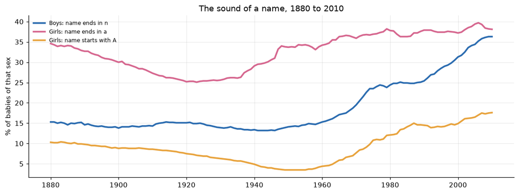

|  | year | boys_ending_n_pct | girls_ending_a_pct | girls_starting_a_pct |
| --- | --- | --- | --- | --- |
| 0 | 1880 | 15.3 | 34.6 | 10.3 |
| 45 | 1925 | 14.8 | 25.4 | 6.9 |
| 70 | 1950 | 14.1 | 33.7 | 3.5 |
| 95 | 1975 | 23.5 | 36.9 | 10.8 |
| 120 | 2000 | 31.3 | 37.2 | 14.9 |
| 130 | 2010 | 36.3 | 38.1 | 17.6 |

```python
letters = q("""
SELECT year,
       ROUND(100.0 * SUM(CASE WHEN sex = 'M' AND substr(name, -1) = 'n' THEN births END)
             / SUM(CASE WHEN sex = 'M' THEN births END), 1) AS boys_ending_n_pct,
       ROUND(100.0 * SUM(CASE WHEN sex = 'F' AND substr(name, -1) = 'a' THEN births END)
             / SUM(CASE WHEN sex = 'F' THEN births END), 1) AS girls_ending_a_pct,
       ROUND(100.0 * SUM(CASE WHEN sex = 'F' AND substr(name, 1, 1) = 'A' THEN births END)
             / SUM(CASE WHEN sex = 'F' THEN births END), 1) AS girls_starting_a_pct
FROM names
GROUP BY year
ORDER BY year
""")

fig, ax = plt.subplots(figsize=(10.5, 4))
ax.plot(letters.year, letters.boys_ending_n_pct, color=BLUE, lw=2.4, label="Boys: name ends in n")
ax.plot(letters.year, letters.girls_ending_a_pct, color=PINK, lw=2.4, label="Girls: name ends in a")
ax.plot(letters.year, letters.girls_starting_a_pct, color=AMBER, lw=2.4, label="Girls: name starts with A")
ax.set_ylabel("% of babies of that sex")
ax.legend(frameon=False, fontsize=8, loc="upper left")
ax.set_title("The sound of a name, 1880 to 2010")
fig.tight_layout()
plt.show()  # use plt.savefig(...) to save instead

letters[letters.year.isin([1880, 1925, 1950, 1975, 2000, 2010])]
```

## 9. How fast does a fad fall?

A **recursive CTE** builds a calendar of years, which is cross-joined with every name of at least 100,000 births so that missing years become zeros. A centred five-year moving average (`ROWS BETWEEN 2 PRECEDING AND 2 FOLLOWING`) removes single-year noise, a window finds each name's peak, and a self-join finds the first later year in which the average is under half of the peak. The shorter the gap, the more of a fad the name was. Peaks up to 1990 only, so that every name has at least 20 years to fall; names that never fell by half come last.

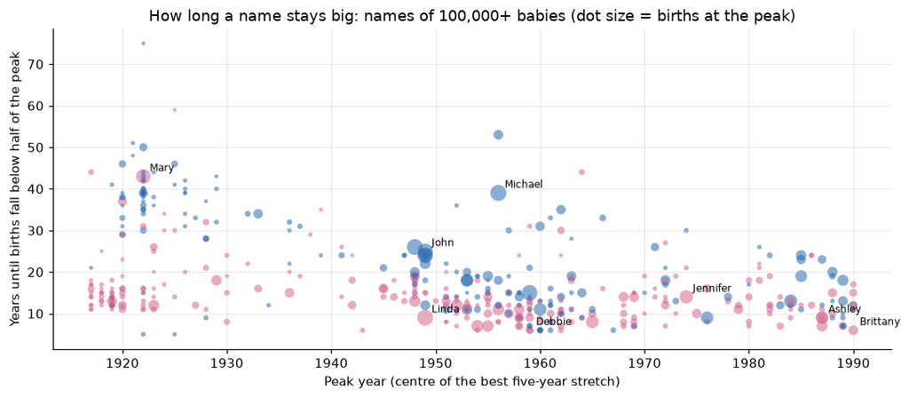

| peak_decade | names | fell_by_half | median_years |
| --- | --- | --- | --- |
| 1910 | 42 | 42 | 14.0 |
| 1920 | 91 | 91 | 32.0 |
| 1930 | 19 | 19 | 22.0 |
| 1940 | 44 | 44 | 18.0 |
| 1950 | 93 | 93 | 12.0 |
| 1960 | 65 | 65 | 11.0 |
| 1970 | 30 | 29 | 14.0 |
| 1980 | 59 | 52 | 12.0 |
| 1990 | 9 | 7 | 12.0 |

```python
fads = q("""
WITH RECURSIVE years(y) AS (
    SELECT 1880 UNION ALL SELECT y + 1 FROM years WHERE y < 2010
),
big AS (
    SELECT name, sex, SUM(births) AS total FROM names GROUP BY name, sex HAVING SUM(births) >= 100000
),
filled AS (
    SELECT b.name, b.sex, y.y AS year, COALESCE(n.births, 0) AS births
    FROM big b
    CROSS JOIN years y
    LEFT JOIN names n ON n.name = b.name AND n.sex = b.sex AND n.year = y.y
),
smooth AS (
    SELECT name, sex, year, births,
           AVG(births) OVER (PARTITION BY name, sex ORDER BY year ROWS BETWEEN 2 PRECEDING AND 2 FOLLOWING) AS avg5
    FROM filled
),
peak AS (
    SELECT name, sex, year AS peak_year, avg5 AS peak_avg5,
           ROW_NUMBER() OVER (PARTITION BY name, sex ORDER BY avg5 DESC, year) AS rn
    FROM smooth
),
fall AS (
    SELECT p.name, p.sex, MIN(s.year) AS half_year
    FROM peak p
    JOIN smooth s ON s.name = p.name AND s.sex = p.sex AND s.year > p.peak_year AND s.avg5 * 2 < p.peak_avg5
    WHERE p.rn = 1
    GROUP BY p.name, p.sex
)
SELECT p.name, p.sex, p.peak_year, ROUND(p.peak_avg5) AS peak_births_per_year,
       f.half_year - p.peak_year AS years_to_halve
FROM peak p
LEFT JOIN fall f USING (name, sex)
WHERE p.rn = 1 AND p.peak_year <= 1990
ORDER BY years_to_halve IS NULL, years_to_halve, p.peak_avg5 DESC
""")

d = fads.dropna(subset=["years_to_halve"])
fig, ax = plt.subplots(figsize=(10, 4.4))
ax.scatter(d.peak_year, d.years_to_halve, s=d.peak_births_per_year / 600 + 6, c=[PINK if s == "F" else BLUE for s in d.sex], alpha=0.55, edgecolor="none")
for name in ("Brittany", "Linda", "Ashley", "Jennifer", "John", "Michael", "Mary", "Debbie"):
    r = d[d.name == name].iloc[0]
    ax.annotate(name, (r.peak_year, r.years_to_halve), xytext=(5, 4), textcoords="offset points", fontsize=8)
ax.set_xlabel("Peak year (centre of the best five-year stretch)")
ax.set_ylabel("Years until births fall below half of the peak")
ax.set_title("How long a name stays big: names of 100,000+ babies (dot size = births at the peak)")
fig.tight_layout()
plt.show()  # use plt.savefig(...) to save instead

fads.assign(peak_decade=fads.peak_year // 10 * 10).groupby('peak_decade').years_to_halve.agg(names='size', fell_by_half='count', median_years='median')
```

## What the queries say

- **Names have spread out, and boys and girls have converged.** The ten most popular boys' names covered 44.2% of boys in 1880 and 9.0% in 2010; for girls the figure went from 24.6% to 8.9%, so by 2010 the two are almost equal. Naming half of all boys took 14 names in 1880 and 117 in 2010; for girls it took 38 and 246. The fall was not steady: the girls' top ten held between 22% and 26% for the thirty years from 1920 to 1950 and only then began to loosen.
- **Variety fell first and then rose, but the yearly comparison needs care.** Distinct names per thousand babies fell from 10.4 (girls, 1880) to 3.6 (1950) and rose to 11.2 (2010); for boys from 9.6 to 2.3 to 7.4. The ratio depends on how many babies there are (91,000 girls in 1880, 1.76 million in 2010), so it shows direction, not an exact index.
- **The all-time list is short and almost entirely male.** James (5,049,727 babies) is a hair ahead of John (5,040,319), then come Robert, Michael and Mary, the only girl in the top ten, with 4,103,935. Each of the top three boys' names covers 2.9% to 3.1% of all boys born in the 131 years; Mary covers 2.6% of all girls.
- **Number one was a long job until the 1960s.** Mary was the most common girls' name for 67 years in a row (1880-1946) and John the most common boys' name for 44 (1880-1923). Michael held the top spot for 38 years (1961-1998). Later spells are much shorter: Jennifer 15 years, Emily 12, Jacob 12 (and still going when the data ends in 2010).
- **One-year jumps line up with famous things, and they have different shapes.** Tammy went from 261 babies in 1956 to 4,361 in 1957 (16.7 times) and then stayed in fashion for a decade, peaking at 21,185 in 1963. Jaime jumped from 914 to 7,838 in 1976 and Ashanti from 281 to 2,944 in 2002; both were at their peak in the jump year and fell back fast (Jaime to 3,086 by 1979, Ashanti to 532 by 2004). Dawson went from 209 to 1,895 in 1998, rose once more to 2,801 in 1999 and then slid slowly to 1,155 by 2010. The dates match a film and a hit song (Tammy), a television series (Jaime, Dawson) and a singer's first album (Ashanti), but the data can only show the timing, not the cause.
- **Names change sex in one direction.** Ten names that were nearly all male in some decade and nearly all female in another all moved from boys to girls: Leslie, Kelly, Lauren, Shelby, Lindsey, Morgan, Sandy, Aubrey, Addison and Madison. Aubrey was 2.7% girls in the 1950s and 97.4% in the 2010s. Madison had no girls at all in 1983, 41 in 1984 (the year of the film Splash), 645 in 1986, and was 85% girls in the 1980s and 99.5% in the 2000s. Among names with at least 50,000 babies, none did the reverse.
- **The sound of names moved.** Boys given a name ending in n rose from 14.1% in 1950 to 36.3% in 2010. Girls' names starting with A went from 3.5% to 17.6%, a fivefold rise, while the share ending in a was 34.6% in 1880, dipped to 25.4% in 1925 and reached 38.1% in 2010.
- **Fads fall faster than classics.** Among the 452 names with 100,000 or more babies, the median time to fall below half of the peak was 32 years for names that peaked in the 1920s, against 11 to 14 years for peaks between 1950 and 1990. Brittany (peak 1990, about 31,000 a year) halved in 6 years, Linda and Ashley in 9, Jennifer in 14, John in 25, Michael in 39 and Mary in 43. Only 10 of the 452 names had not fallen by half by 2010, all with later peaks.

**What to be careful about.** The data lists names given to at least five babies of one sex in a year, so rare names are missing and the share of the ten most popular names is slightly overstated, more so in the early years. The "years to halve" measure is cut off at 2010: names that peaked around 1990 had less time to fall, so their medians lean low. Spelling variants (Jaime, Jamie, Jaimie) are separate rows, so a fashion can be spread over several of them.